# rdsm

2024-2025 MOIELWAY NGARTI Israël **PROJET D’ANALYSE MULTIVARIEE DES POLLUANTS ATMOSPHERIQUES A PERIGUEUX.**  
M1IREF RDSM

# Contexte

La pollution atmosphérique constitue un défi majeur pour la santé publique et l’environnement, en particulier dans les zones urbaines où les activités humaines et les conditions météorologiques jouent un rôle important. Ce projet se concentre sur l’étude de la qualité de l’air à Périgueux en 2024, avec pour objectif d’analyser l’influence des paramètres météorologiques sur les niveaux de pollution, notamment ceux de l’Ozone (O3) et des particules fines (PM10).

Grâce à des données collectées auprès d’Infoclimat et d’ATMO France, une exploration statistique approfondie a été réalisée à l’aide de techniques comme l’Analyse en Composantes Principales (ACP). Cette analyse vise à mettre en évidence les relations entre variables, identifier des périodes critiques et proposer des pistes d’interprétation pour mieux comprendre les mécanismes sous-jacents

```r
library(tidyr)
library(dplyr)
library(ggplot2)
library(lubridate) # pour la gestion des format date
library(MASS)
library(FactoMineR)
library(corrplot)
library(factoextra)
library(plotly)
# manipulation pour les données manquantes
library(naniar)
# si on veut faire de l'ACP en dynamique, ie explorer et voir directement le rendu
library(Factoshiny)
```

On décide de supprimer la variables PM2.5, et ensuite de nettoyer les lignes où des NA subsistent

On crée une variable qui donne le jour de mesure, ainsi que l’heure :

Puis, en cas de besoin, un vecteur des identifiants avec une info sur la date et l’heure :

## La Matrice de corrélation des variables

```r
# Calcul de la matrice de corrélation pour les variables quantitatives
quant_vars <- df %>% select(where(is.numeric))
Matrix<-round(cor(quant_vars),3) #fonction round pour arrondir à 3 décimales
# Matrice en HTML simple
html_table <- htmlTable::htmlTable(Matrix, caption = "Matrice de corrélation des variables quantitatives")
html_table
```

| Matrice de corrélation des variables quantitatives | Matrice de corrélation des variables quantitatives date_debut_standard | Matrice de corrélation des variables quantitatives NO2 | Matrice de corrélation des variables quantitatives O3 | Matrice de corrélation des variables quantitatives NO | Matrice de corrélation des variables quantitatives PM10 | Matrice de corrélation des variables quantitatives temperature | Matrice de corrélation des variables quantitatives pression | Matrice de corrélation des variables quantitatives pression_variation_3h | Matrice de corrélation des variables quantitatives humidite | Matrice de corrélation des variables quantitatives point_de_rosee | Matrice de corrélation des variables quantitatives vent_moyen | Matrice de corrélation des variables quantitatives vent_rafales | Matrice de corrélation des variables quantitatives vent_rafales_10min | Matrice de corrélation des variables quantitatives vent_direction | Matrice de corrélation des variables quantitatives temperature_min | Matrice de corrélation des variables quantitatives temperature_max | Matrice de corrélation des variables quantitatives pluie_1h | Matrice de corrélation des variables quantitatives pluie_3h | Matrice de corrélation des variables quantitatives pluie_6h | Matrice de corrélation des variables quantitatives pluie_12h | Matrice de corrélation des variables quantitatives pluie_24h | Matrice de corrélation des variables quantitatives pluie_cumul_0h | Matrice de corrélation des variables quantitatives pluie_intensite | Matrice de corrélation des variables quantitatives pluie_intensite_max_1h | Matrice de corrélation des variables quantitatives heure |
| --- | --- | --- | --- | --- | --- | --- | --- | --- | --- | --- | --- | --- | --- | --- | --- | --- | --- | --- | --- | --- | --- | --- | --- | --- | --- |
| date_debut_standard | 1 | -0.283 | 0.073 | -0.231 | -0.094 | 0.581 | -0.14 | 0.003 | -0.194 | 0.611 | -0.114 | -0.055 | -0.06 | 0.055 | 0.597 | 0.575 | -0.018 | -0.014 | -0.006 | 0.017 | 0.089 | -0.036 | -0.01 | 0.031 | 0.003 |
| NO2 | -0.283 | 1 | -0.497 | 0.876 | 0.49 | -0.382 | 0.2 | 0.121 | 0.287 | -0.305 | -0.262 | 0.014 | -0.292 | -0.119 | -0.378 | -0.274 | -0.01 | -0.026 | -0.037 | -0.049 | -0.075 | 0.012 | -0.003 | -0.012 | 0.17 |
| O3 | 0.073 | -0.497 | 1 | -0.54 | -0.318 | 0.473 | -0.287 | -0.022 | -0.612 | 0.219 | 0.436 | 0.013 | 0.478 | 0.254 | 0.233 | 0.454 | 0.053 | 0.076 | 0.094 | 0.111 | 0.098 | 0.13 | 0.046 | 0.044 | 0.309 |
| NO | -0.231 | 0.876 | -0.54 | 1 | 0.528 | -0.34 | 0.237 | 0.08 | 0.242 | -0.28 | -0.218 | 0.016 | -0.244 | -0.16 | -0.353 | -0.275 | -0.037 | -0.059 | -0.072 | -0.083 | -0.103 | -0.044 | -0.019 | -0.029 | 0.094 |
| PM10 | -0.094 | 0.49 | -0.318 | 0.528 | 1 | -0.053 | 0.217 | -0.026 | 0.049 | -0.043 | -0.197 | 0.006 | -0.205 | -0.106 | -0.095 | -0.012 | -0.144 | -0.198 | -0.222 | -0.205 | -0.195 | -0.183 | -0.083 | -0.087 | 0.055 |
| temperature | 0.581 | -0.382 | 0.473 | -0.34 | -0.053 | 1 | -0.191 | -0.159 | -0.633 | 0.846 | 0.184 | -0.009 | 0.239 | 0.107 | 0.746 | 0.902 | -0.04 | -0.042 | -0.04 | -0.037 | -0.038 | -0.043 | -0.02 | 0.007 | 0.205 |
| pression | -0.14 | 0.2 | -0.287 | 0.237 | 0.217 | -0.191 | 1 | 0.059 | 0.028 | -0.225 | -0.174 | -0.01 | -0.208 | 0.048 | -0.239 | -0.171 | -0.239 | -0.294 | -0.324 | -0.342 | -0.333 | -0.315 | -0.154 | -0.133 | -0.012 |
| pression_variation_3h | 0.003 | 0.121 | -0.022 | 0.08 | -0.026 | -0.159 | 0.059 | 1 | 0.257 | -0.026 | -0.091 | -0.002 | -0.093 | 0.209 | 0.046 | -0.014 | 0.043 | 0.075 | 0.123 | 0.149 | 0.14 | 0.21 | 0.032 | 0.041 | 0.151 |
| humidite | -0.194 | 0.287 | -0.612 | 0.242 | 0.049 | -0.633 | 0.028 | 0.257 | 1 | -0.163 | -0.423 | -0.01 | -0.448 | -0.098 | -0.122 | -0.543 | 0.164 | 0.199 | 0.211 | 0.209 | 0.192 | 0.185 | 0.092 | 0.083 | -0.288 |
| point_de_rosee | 0.611 | -0.305 | 0.219 | -0.28 | -0.043 | 0.846 | -0.225 | -0.026 | -0.163 | 1 | -0.024 | -0.169 | 0.049 | 0.089 | 0.893 | 0.828 | 0.046 | 0.068 | 0.081 | 0.086 | 0.078 | 0.067 | 0.022 | 0.062 | 0.085 |
| vent_moyen | -0.114 | -0.262 | 0.436 | -0.218 | -0.197 | 0.184 | -0.174 | -0.091 | -0.423 | -0.024 | 1 | 0.046 | 0.893 | 0.117 | -0.016 | 0.078 | 0.069 | 0.084 | 0.086 | 0.078 | 0.066 | 0.09 | 0.067 | 0.015 | 0.1 |
| vent_rafales | -0.055 | 0.014 | 0.013 | 0.016 | 0.006 | -0.009 | -0.01 | -0.002 | -0.01 | -0.169 | 0.046 | 1 | -0.093 | -0.004 | -0.149 | -0.174 | 0.016 | -0.014 | -0.028 | -0.034 | -0.038 | -0.036 | 0.048 | -0.013 | 0.018 |
| vent_rafales_10min | -0.06 | -0.292 | 0.478 | -0.244 | -0.205 | 0.239 | -0.208 | -0.093 | -0.448 | 0.049 | 0.893 | -0.093 | 1 | 0.106 | 0.047 | 0.146 | 0.085 | 0.111 | 0.12 | 0.117 | 0.106 | 0.12 | 0.075 | 0.026 | 0.11 |
| vent_direction | 0.055 | -0.119 | 0.254 | -0.16 | -0.106 | 0.107 | 0.048 | 0.209 | -0.098 | 0.089 | 0.117 | -0.004 | 0.106 | 1 | 0.145 | 0.132 | 0.038 | 0.05 | 0.065 | 0.079 | 0.056 | 0.106 | 0.031 | 0.03 | 0.102 |
| temperature_min | 0.597 | -0.378 | 0.233 | -0.353 | -0.095 | 0.746 | -0.239 | 0.046 | -0.122 | 0.893 | -0.016 | -0.149 | 0.047 | 0.145 | 1 | 0.727 | 0.034 | 0.056 | 0.076 | 0.097 | 0.104 | 0.063 | 0.013 | 0.041 | -0.08 |
| temperature_max | 0.575 | -0.274 | 0.454 | -0.275 | -0.012 | 0.902 | -0.171 | -0.014 | -0.543 | 0.828 | 0.078 | -0.174 | 0.146 | 0.132 | 0.727 | 1 | -0.032 | -0.032 | -0.03 | -0.032 | -0.036 | 0.005 | -0.023 | 0.034 | 0.416 |
| pluie_1h | -0.018 | -0.01 | 0.053 | -0.037 | -0.144 | -0.04 | -0.239 | 0.043 | 0.164 | 0.046 | 0.069 | 0.016 | 0.085 | 0.038 | 0.034 | -0.032 | 1 | 0.748 | 0.593 | 0.441 | 0.305 | 0.413 | 0.617 | 0.44 | 0.013 |
| pluie_3h | -0.014 | -0.026 | 0.076 | -0.059 | -0.198 | -0.042 | -0.294 | 0.075 | 0.199 | 0.068 | 0.084 | -0.014 | 0.111 | 0.05 | 0.056 | -0.032 | 0.748 | 1 | 0.839 | 0.634 | 0.436 | 0.567 | 0.432 | 0.342 | 0.02 |
| pluie_6h | -0.006 | -0.037 | 0.094 | -0.072 | -0.222 | -0.04 | -0.324 | 0.123 | 0.211 | 0.081 | 0.086 | -0.028 | 0.12 | 0.065 | 0.076 | -0.03 | 0.593 | 0.839 | 1 | 0.813 | 0.557 | 0.668 | 0.334 | 0.272 | 0.026 |
| pluie_12h | 0.017 | -0.049 | 0.111 | -0.083 | -0.205 | -0.037 | -0.342 | 0.149 | 0.209 | 0.086 | 0.078 | -0.034 | 0.117 | 0.079 | 0.097 | -0.032 | 0.441 | 0.634 | 0.813 | 1 | 0.729 | 0.715 | 0.233 | 0.207 | 0.021 |
| pluie_24h | 0.089 | -0.075 | 0.098 | -0.103 | -0.195 | -0.038 | -0.333 | 0.14 | 0.192 | 0.078 | 0.066 | -0.038 | 0.106 | 0.056 | 0.104 | -0.036 | 0.305 | 0.436 | 0.557 | 0.729 | 1 | 0.61 | 0.171 | 0.141 | 0 |
| pluie_cumul_0h | -0.036 | 0.012 | 0.13 | -0.044 | -0.183 | -0.043 | -0.315 | 0.21 | 0.185 | 0.067 | 0.09 | -0.036 | 0.12 | 0.106 | 0.063 | 0.005 | 0.413 | 0.567 | 0.668 | 0.715 | 0.61 | 1 | 0.235 | 0.216 | 0.245 |
| pluie_intensite | -0.01 | -0.003 | 0.046 | -0.019 | -0.083 | -0.02 | -0.154 | 0.032 | 0.092 | 0.022 | 0.067 | 0.048 | 0.075 | 0.031 | 0.013 | -0.023 | 0.617 | 0.432 | 0.334 | 0.233 | 0.171 | 0.235 | 1 | 0.328 | 0.017 |
| pluie_intensite_max_1h | 0.031 | -0.012 | 0.044 | -0.029 | -0.087 | 0.007 | -0.133 | 0.041 | 0.083 | 0.062 | 0.015 | -0.013 | 0.026 | 0.03 | 0.041 | 0.034 | 0.44 | 0.342 | 0.272 | 0.207 | 0.141 | 0.216 | 0.328 | 1 | 0.067 |
| heure | 0.003 | 0.17 | 0.309 | 0.094 | 0.055 | 0.205 | -0.012 | 0.151 | -0.288 | 0.085 | 0.1 | 0.018 | 0.11 | 0.102 | -0.08 | 0.416 | 0.013 | 0.02 | 0.026 | 0.021 | 0 | 0.245 | 0.017 | 0.067 | 1 |

### Analyse globale

#### Corrélations Positives

NO2 :

NO (0.876) : Une forte corrélation positive indique que des niveaux élevés de NO2 sont associés à des niveaux élevés de NO. Cela peut être dû à des sources communes de pollution, comme les émissions des véhicules.

PM10 (0.49) : Une corrélation positive montre que des niveaux élevés de NO2 sont associés à des niveaux élevés de PM10.Cela peut indiquer que les zones avec une pollution élevée en NO2 ont également des niveaux élevés de particules fines.

O3 :

vent_moyen (0.436) :Des niveaux élevés d’O3 sont associés à des vitesses de vent moyennes plus élevées. Cela peut indiquer que le vent aide à disperser l’ozone dans l’atmosphère..

temperature (0.473) : Une corrélation positive montre que des niveaux élevés d’O3 sont associés à des températures plus élevées.Cela peut s’expliquer par le fait que l’ozone se forme plus facilement à des températures plus élevées.

NO :

PM10 (0.528) : PM10 (0.528) : Des niveaux élevés de NO sont associés à des niveaux élevés de PM10. Cela peut indiquer que les zones avec une pollution élevée en NO ont également des niveaux élevés de particules fines.

temperature :

point_de_rosee (0.846) : Une forte corrélation positive montre que des températures plus élevées sont associées à des points de rosée plus élevés.

temperature_max (0.902) : Des températures plus élevées sont associées à des températures maximales plus élevées. Cela indique que les journées chaudes sont encore plus chaudes.

point_de_rosee :

temperature_min (0.893) : Des points de rosée plus élevés sont associés à des températures minimales plus élevées. Cela signifie que l’air est plus humide pendant les nuits chaudes.

temperature_max (0.828) : Des points de rosée plus élevés sont associés à des températures maximales plus élevées. Cela signifie que l’air est plus humide pendant les journées chaudes.

vent_moyen :

vent_rafales_10min (0.893) : Des vitesses de vent moyennes plus élevées sont associées à des rafales de vent plus élevées sur 10 minutes. Cela signifie que les périodes de vent fort sont souvent accompagnées de rafales.

#### Corrélations Négatives

O3 :

humidite (-0.612) : Des niveaux élevés d’O3 sont associés à des niveaux plus faibles d’humidité. Cela peut indiquer que l’ozone se forme plus facilement dans des conditions sèches.

NO (-0.54) : Des niveaux élevés d’O3 sont associés à des niveaux plus faibles de NO. Cela peut indiquer que les sources de NO, comme les émissions des véhicules, réduisent les niveaux d’ozone.

humidite :

temperature (-0.633) : Des niveaux plus élevés d’humidité sont associés à des températures plus faibles. Cela peut indiquer que l’air est plus humide à des températures plus basses.

### Les variables corrélées avec O3

En se basant sur la matrice de corrélation on observe que les variables: NO(-0,540), et humidité(-0,612) sont liées négativement à l’ozone. Temperature maximum(0,454), vents_rafales_10min(0,478), vent_moyen(0,436) et temperature(0,473) sont liées positivement à l’ozone.

### Les graphiques pertinents montrant la liaison

Ces graphiques montrent la relation entre l’ozone et quelques variables.

### Relation entre la température et l’ozone

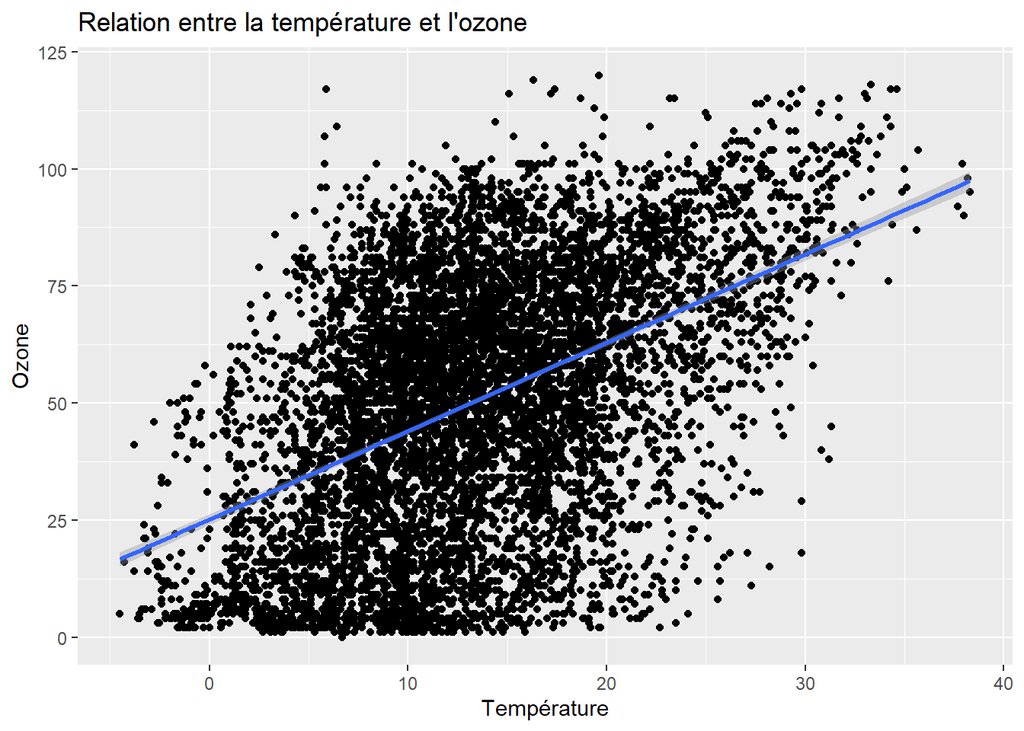

```r
# Graphiques pertinents
ggplot(df, aes(x = temperature, y = O3)) +
  geom_point() +
  geom_smooth(method = "lm") +
  labs(title = "Relation entre la température et l'ozone", x = "Température", y = "Ozone")
```

Relation entre l’humidité et l’ozone

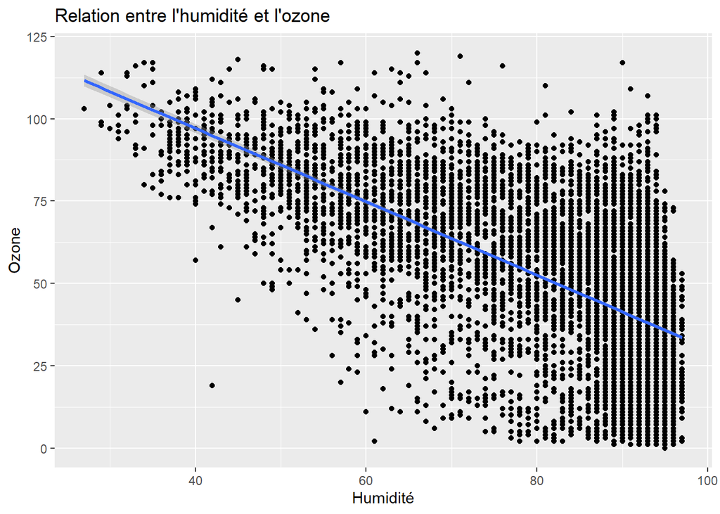

```r
# Graphiques pertinents
ggplot(df, aes(x = humidite, y = O3)) +
  geom_point() +
  geom_smooth(method = "lm") +
  labs(title = "Relation entre l'humidité et l'ozone", x = "Humidité", y = "Ozone")
```

Relation entre l’azote(NO) et l’ozone(O3)

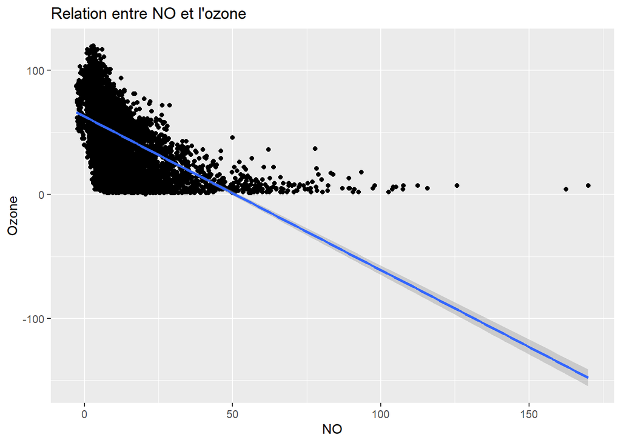

```r
ggplot(df, aes(x = NO, y = O3)) +
  geom_point() +
  geom_smooth(method = "lm") +
  labs(title = "Relation entre NO et l'ozone", x = "NO", y = "Ozone")
```

## Représentation des boites à moustaches parallèles de la variable Ozone, en fonction de l’heure de la journée.

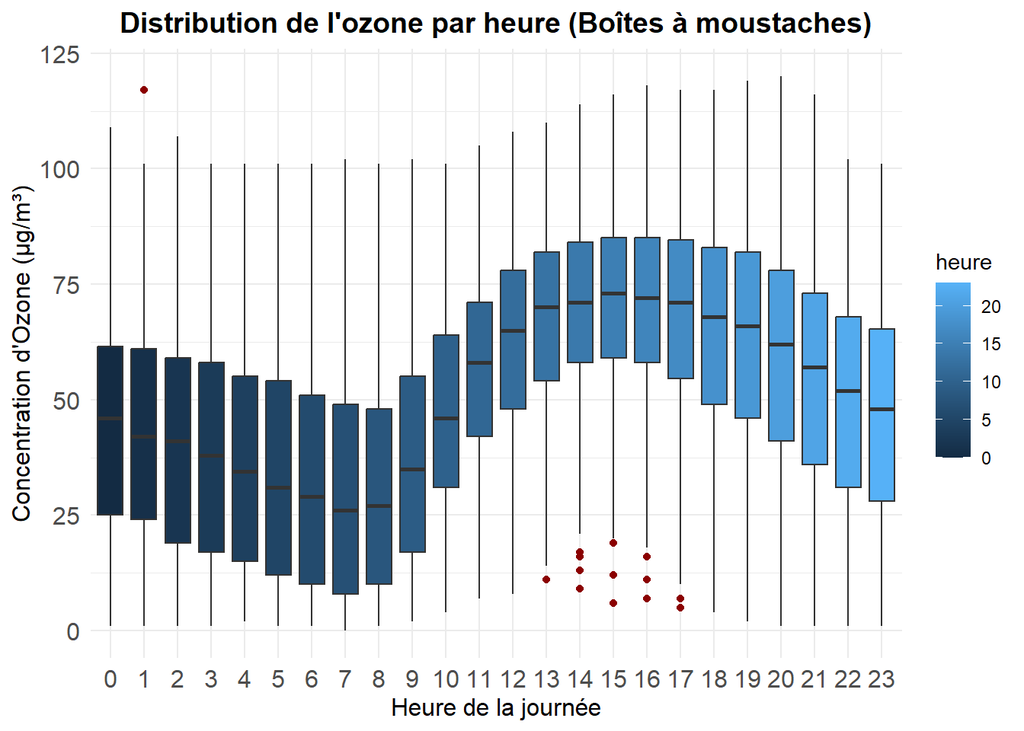

```r
# Graphique des boîtes à moustaches de l'ozone par heure
ggplot(df, aes(x = factor(heure), y = O3, fill=heure)) +  # Couleurs par heure
  geom_boxplot(outlier.color = "darkred", outlier.shape = 19) +  # Points aberrants en rouge
  labs(
    title = "Distribution de l'ozone par heure (Boîtes à moustaches)",
    x = "Heure de la journée",
    y = "Concentration d'Ozone (µg/m³)"
  ) +
  theme_minimal() +  # Style propre et lisible
  theme(
    plot.title = element_text(hjust = 0.5, size = 14, face = "bold"),  # Titre centré et en gras
    axis.title = element_text(size = 12),  # Taille des titres des axes
    axis.text = element_text(size = 12),  # Taille des textes des axes
  )
```

#### Commentaires.

Les concentrations d’ozone augmentent progressivement à partir de 9h, atteignent un pic entre 14h et 16h, puis diminuent progressivement après 17h. Les concentrations sont les plus basses durant la nuit (0h - 7h).

Dispersion :

Pendant les heures de pointe de la journée (12h - 16h), les moustaches sont plus courtes, ce qui indique une plus faible variabilité. Cela peut refléter des conditions météorologiques stables. La nuit, la dispersion est plus élevée, suggérant des variations importantes dues à d’autres facteurs.

Valeurs aberrantes :

Quelques valeurs aberrantes sont visibles, principalement en milieu de journée et la nuit. Ces points peuvent représenter des événements ponctuels de pollution ou des erreurs de mesure.

Interprétation :

Pic en journée (14h - 16h) : L’ozone est produit par la photodissociation des polluants sous l’effet du rayonnement solaire. Baisse nocturne : En l’absence de lumière solaire, la production d’ozone diminue et sa concentration est réduite par des réactions chimiques.

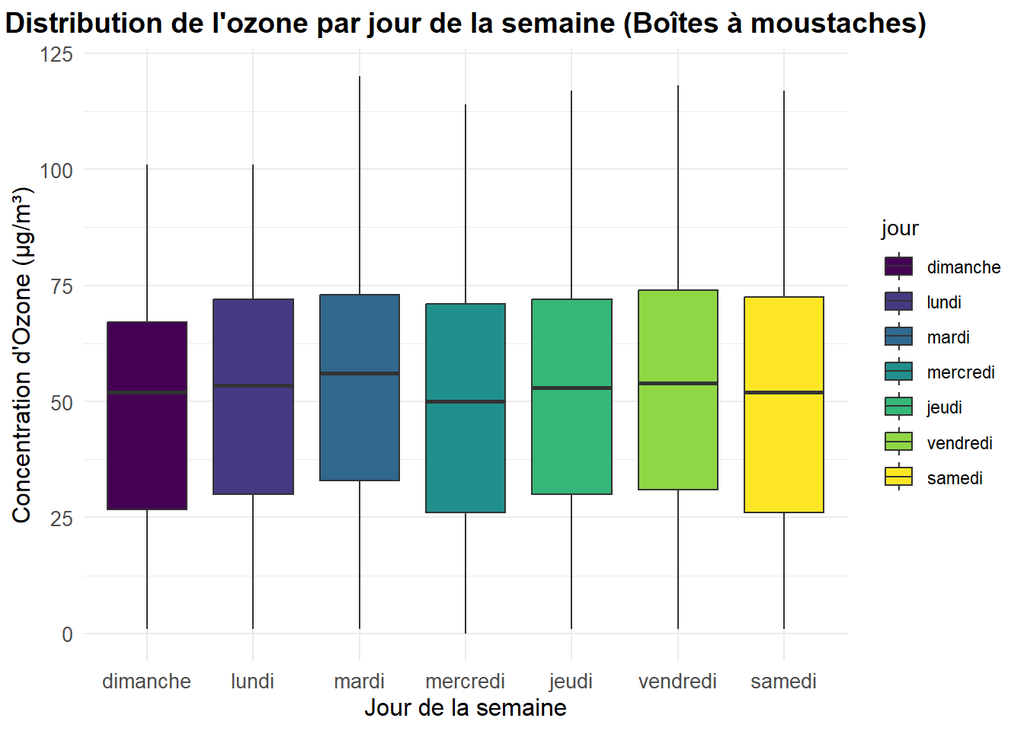

```r
# Graphique des boîtes à moustaches de l'ozone par jour de la semaine
ggplot(df, aes(x = jour, y = O3,fill= jour)) +
  geom_boxplot(outlier.color = "black", outlier.shape = 19) +  # Points aberrants en noir, boîtes blanches
  labs(
    title = "Distribution de l'ozone par jour de la semaine (Boîtes à moustaches)",
    x = "Jour de la semaine",
    y = "Concentration d'Ozone (µg/m³)"
  ) +
  theme_minimal() +  # Style minimaliste
  theme(
    plot.title = element_text(hjust = 0.5, size = 14, face = "bold"),
    axis.title = element_text(size = 12),
    axis.text = element_text(size = 10),

  )
```

Commentaires.

Les médianes sont relativement similaires pour tous les jours de la semaine. La concentration en ozone ne semble pas varier de manière significative entre les jours.

Dispersion :

Les dispersions (écarts entre les moustaches supérieure et inférieure) sont également assez homogènes. La distribution est globalement stable pour tous les jours de la semaine, sans jours particulièrement atypiques.

Interprétation :

La concentration d’ozone semble suivre une tendance uniforme sur les jours de la semaine. Les activités humaines n’ont pas un effet marqué sur les variations journalières de l’ozone à périgueux.

## Analyse en Composantes Principales du jeu de données complet.

Nous allons faire une ACP normée car les variables n’ont pas les mêmes unités, étant donné que l’ACP permet de déterminer la distance entre les individus et la relation entre les variables alors si les variables mesurées sur des échelles diérentes, les variables de forte variance auront plus de poids dans le calcul de la distance Euclidienne que les variables de petite variance. Ainsi centrer-réduire les données permet donc de donner le même poids à toutes les variables dans le calcul de la distance entre deux individus.

```r
# Exclure les deux dates et   mettre la variable qualitative jour en supplementaire pour l'ACP
acp_complète <- PCA(df %>% select(-date_debut,-date_debut_standard),
                   quali.sup = 24,scale.unit = TRUE,graph=F)
```

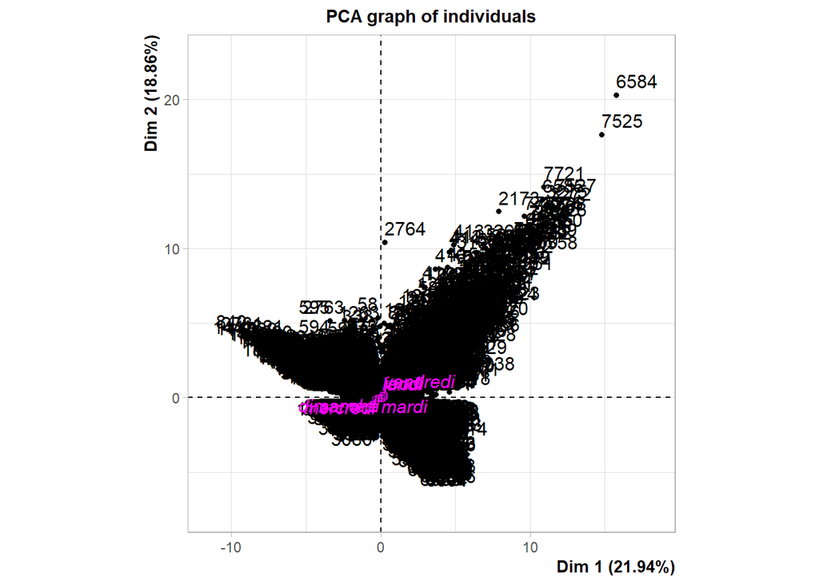

```r
plot.PCA(acp_complète)
```

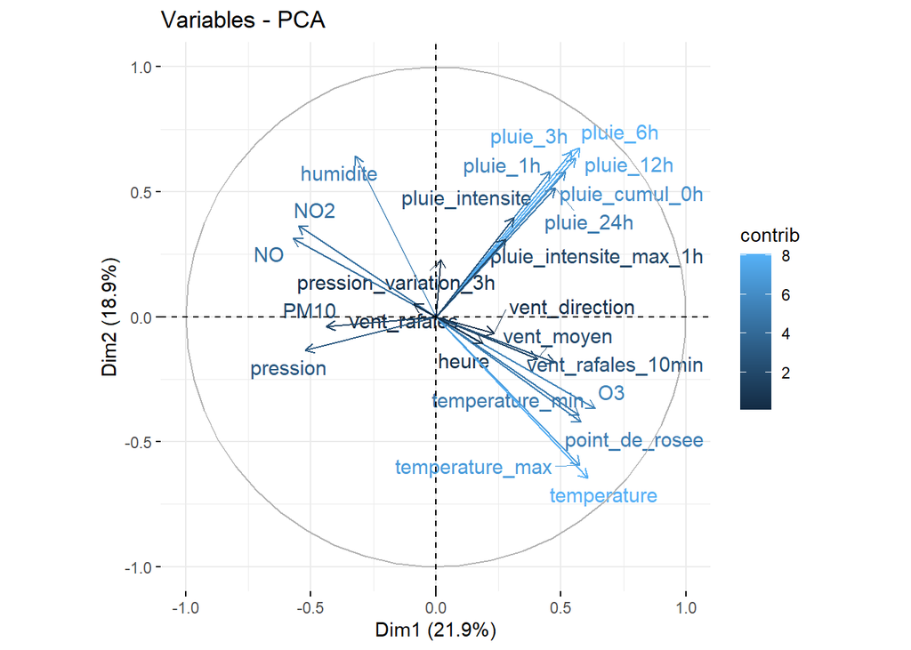

```r
fviz_pca_var(acp_complète, col.var = "contrib", repel = TRUE)
```

### Les contributions des variables :

Ces variables représentent des précipitations et peuvent être liées à des conditions météorologiques spécifiques.

###Liens entre les variables :

Opposition :

Les vecteurs des précipitations (pluie_3h, pluie_6h) semblent en opposition à des variables telles que la pression, indiquant que les précipitations sont associées à des conditions atmosphériques spécifiques. On observe également l’opposition entre les températures et l’humidité; l’ozone (O3) et le dioxyte d’azote(NO2).

## Reprennons l’ACP complète en incluant une seule variable de pluie.

```r
# ACP avec une seule variable de pluie
acp_reduite_pluie <- PCA(df %>% select(-date_debut, -date_debut_standard, -pluie_3h, -pluie_1h, -pluie_12h, -pluie_24h,-pluie_cumul_0h,-pluie_intensite,-pluie_intensite_max_1h),
                        quali.sup = 17, # Variables supplémentaires
                        scale.unit = TRUE, graph = F)
```

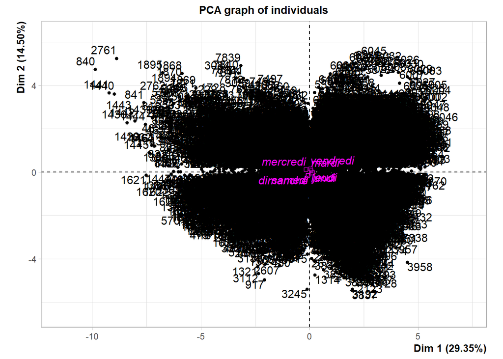

```r
plot.PCA(acp_reduite_pluie)
```

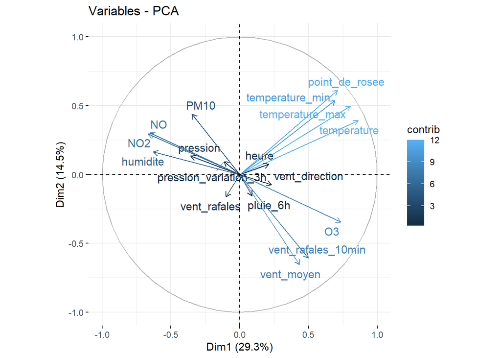

```r
fviz_pca_var(acp_reduite_pluie, col.var = "contrib", repel = TRUE)
```

### Comparaisons avec l’ACP comlplète

Dans le deuxième ACP, les variables de pluie ont été réduites à une seule représentation (par exemple, **pluie_6h**). Cette décision a eu plusieurs impacts sur l’analyse :

**Augmentation de la variance capturée par Dim1 :** - La variance expliquée par **Dim1** est passée de **21.9%** dans le premier ACP à **29.3%** dans le deuxième. Cela indique que les conditions climatiques générales (température, humidité) sont devenues prédominantes dans l’analyse.

**Simplification de l’analyse :** - En supprimant des variables redondantes, le deuxième ACP a permis de recentrer l’analyse sur les interactions principales entre climat et pollution, tout en facilitant l’interprétation.

Ces changements montrent que le retrait des variables de pluie a permis de mieux comprendre l’impact des conditions climatiques générales sur les niveaux de pollution, tout en simplifiant les conclusions.

## Reprennons une ACP en en incluant une seule variable par groupe de variables identiques

```r
# Sélectionner les variables actives pour l'ACP
df_reduit <- df %>%
  select(O3, PM10, temperature_max, vent_moyen, pression, pluie_intensite)

# Sélectionner les variables supplémentaires
var_suppl <- df %>%
  select(NO,NO2)

# Identifier les indices des variables supplémentaires
quanti_sup_indices <- which(names(df) %in% colnames(var_suppl))

# Réaliser l'ACP
acp_reduite <- PCA( df_reduit, scale.unit = TRUE, quanti.sup = quanti_sup_indices,  graph = F)
```

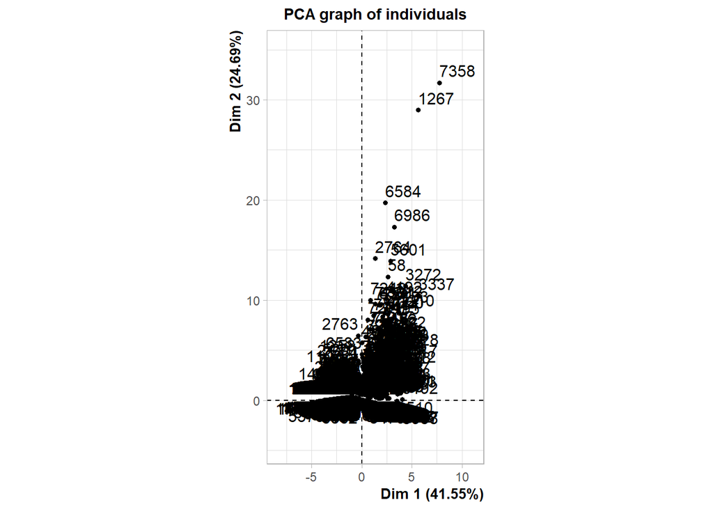

```r
plot.PCA(acp_reduite)
```

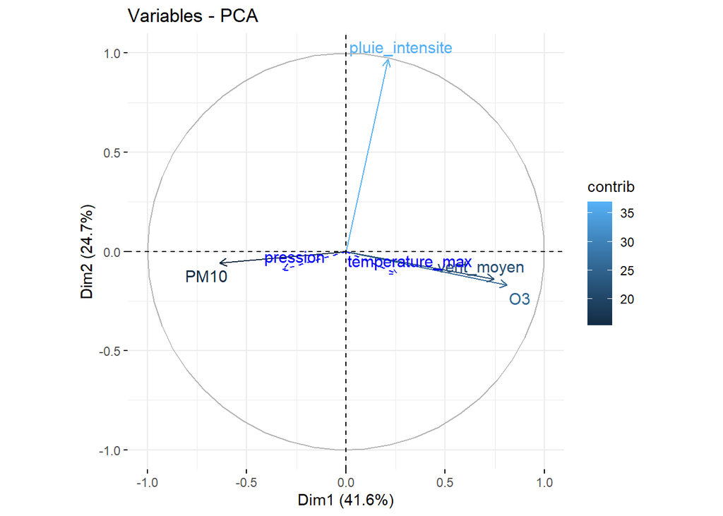

```r
fviz_pca_var(acp_reduite, col.var = "contrib", repel = TRUE)
```

## Travail personnel avec factoshinny

### Problématique

**Comment les conditions météorologiques influencent-elles les niveaux de pollution de l’air à Périgueux ?**

### Analyse exploratoire avec l’ACP

```r
require(Factoshiny)
res <- Factoshiny(df[,-c(1,2)])
```

### Observations et interprétation

- **Variables principales :** les variables météorologiques qui contribuent le plus aux axes principaux sont les précipitations(pluie_6h, pluie_1h, pluie_12), température, humidité).
- **Groupes d’individus :** Identifier des clusters naturels en fonction des conditions de pollution et des variables météorologiques.
- **Moments critiques :** Analyser les individus ayant des coordonnées extrêmes sur les axes principaux pour comprendre les combinaisons de conditions associées aux pics de pollution.

### Analyse complémentaire

```r
# Extraction des moments critiques à partir des résultats ACP (résultats simulés)
ind_coords <- as.data.frame(acp_complète$ind$coord)
critical_ind <- ind_coords %>% filter(Dim.1 > 3 | Dim.2 > 3)

# Caractérisation des moments critiques
critical_periods <- df %>% filter(row.names(df) %in% row.names(critical_ind))
critical_summary <- critical_periods %>%
  summarise(across(c(NO2, NO, O3, PM10, temperature, humidite, vent_moyen), mean))

html_table2 <- htmlTable::htmlTable(critical_summary,caption = "Tableau statistique")
html_table2
```

| Tableau statistique | Tableau statistique NO2 | Tableau statistique NO | Tableau statistique O3 | Tableau statistique PM10 | Tableau statistique temperature | Tableau statistique humidite | Tableau statistique vent_moyen |
| --- | --- | --- | --- | --- | --- | --- | --- |
| 1 | 7.62053571428571 | 10.7389880952381 | 60.6101190476191 | 8.36755952380952 | 13.5571428571429 | 87.3854166666667 | 2.48020833333333 |

### Visualisation des résultats

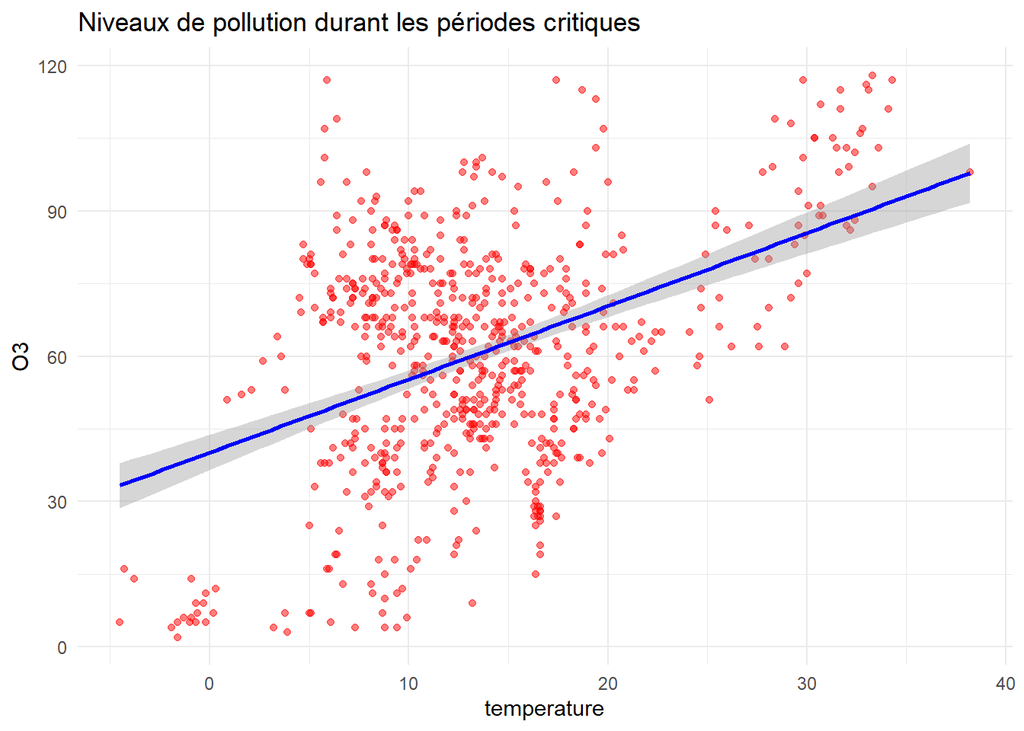

```r
# Distribution des niveaux de pollution pour les périodes critiques
critical_periods %>%
  ggplot(aes(x=temperature, y=O3)) +
  geom_point(alpha=0.5, color="red") +
  geom_smooth(method="lm", color="blue") +
  theme_minimal() +
  ggtitle("Niveaux de pollution durant les périodes critiques")
```

Interprétation : Ce graphique montre une corrélation positive entre la température et les niveaux d’Ozone (O3) durant les périodes critiques. On observe que lorsque la température augmente, les niveaux d’Ozone tendent également à augmenter. Cette relation peut être expliquée par le fait que des températures plus élevées favorisent les réactions photochimiques responsables de la formation d’Ozone.

## Conclusion

Cette étude a démontré l’influence significative des conditions météorologiques sur les niveaux de pollution atmosphérique à Périgueux. À travers l’Analyse en Composantes Principales (ACP) et l’exploration dynamique avec Factoshiny, nous avons identifié des variables clés, telles que la température et l’humidité, qui jouent un rôle crucial dans les variations des niveaux d’Ozone et d’autres polluants.